# HW5

2026-05-06

### Data setup

```r
auto = read_csv("auto.csv")
auto <- na.omit(auto) %>%
  filter(cylinders >= 4 & cylinders <= 8)
auto$origin <- as.factor(auto$origin)
auto$mpg_cat <- as.factor(auto$mpg_cat)

set.seed(2)

data_split <- initial_split(auto, prop = 0.7)
training_data <- training(data_split)
testing_data <- testing(data_split)
```

### 1-a. SVC (Linear Kernel)

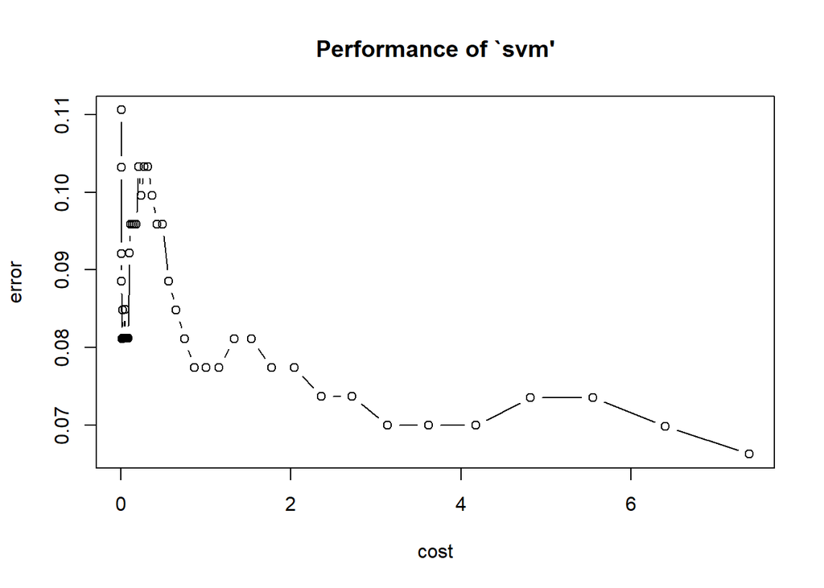

```r
set.seed(2)
linear.tune <- tune.svm(mpg_cat ~ .,
                        data = training_data,
                        kernel = "linear",
                        cost = exp(seq(-5, 2, len = 50)))
plot(linear.tune)
```

```r
best.linear <- linear.tune$best.model
summary(best.linear)
```

```
##
## Call:
## best.svm(x = mpg_cat ~ ., data = training_data, cost = exp(seq(-5,
##     2, len = 50)), kernel = "linear")
##
##
## Parameters:
##    SVM-Type:  C-classification
##  SVM-Kernel:  linear
##        cost:  7.389056
##
## Number of Support Vectors:  54
##
##  ( 28 26 )
##
##
## Number of Classes:  2
##
## Levels:
##  high low
```

```r
# Training Error Rate
pred.train.lin <- predict(best.linear, newdata = training_data)
train_err_lin <- mean(pred.train.lin != training_data$mpg_cat)

# Test Error Rate
pred.test.lin <- predict(best.linear, newdata = testing_data)
test_err_lin <- mean(pred.test.lin != testing_data$mpg_cat)

# Results
cat("SVC Training Error:", train_err_lin, "\n")
```

```
## SVC Training Error: 0.06642066
```

```r
cat("SVC Test Error:", test_err_lin, "\n")
```

```
## SVC Test Error: 0.08547009
```

Training Error = 0.0664 Test Error = 0.0855

### 1-b. SVM (Radial Kernel)

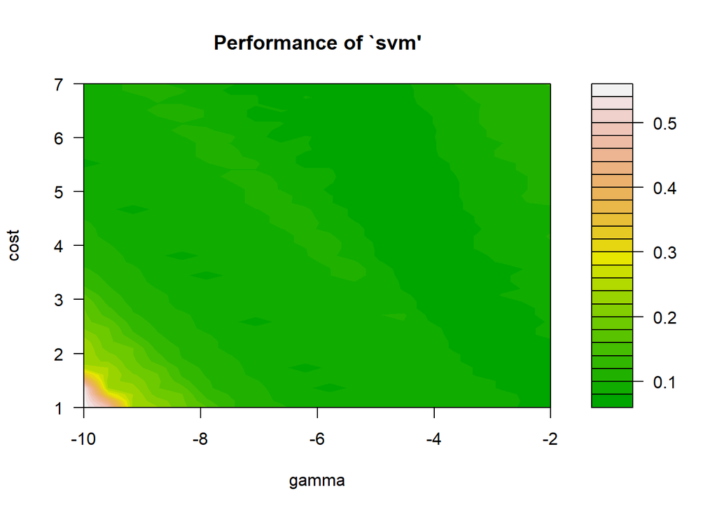

```r
# Fit and tune SVM with Radial Kernel
set.seed(2)
radial.tune <- tune.svm(mpg_cat ~ .,
                        data = training_data,
                        kernel = "radial",
                        cost = exp(seq(1, 7, len = 50)),
                        gamma = exp(seq(-10, -2, len = 20)))

plot(radial.tune, transform.y = log, transform.x = log,
color.palette = terrain.colors)
```

```r
best.radial <- radial.tune$best.model
summary(best.radial)
```

```
##
## Call:
## best.svm(x = mpg_cat ~ ., data = training_data, gamma = exp(seq(-10,
##     -2, len = 20)), cost = exp(seq(1, 7, len = 50)), kernel = "radial")
##
##
## Parameters:
##    SVM-Type:  C-classification
##  SVM-Kernel:  radial
##        cost:  9.248763
##
## Number of Support Vectors:  58
##
##  ( 30 28 )
##
##
## Number of Classes:  2
##
## Levels:
##  high low
```

```r
# Training Error Rate
pred.train.rad <- predict(best.radial, newdata = training_data)
train_err_rad <- mean(pred.train.rad != training_data$mpg_cat)

# Test Error Rate
pred.test.rad <- predict(best.radial, newdata = testing_data)
test_err_rad <- mean(pred.test.rad != testing_data$mpg_cat)

# Results
cat("SVM Training Error:", train_err_rad, "\n")
```

```
## SVM Training Error: 0.05904059
```

```r
cat("SVM Test Error:", test_err_rad, "\n")
```

```
## SVM Test Error: 0.06837607
```

Training Error = 0.059 Test Error = 0.0684

### 1-c. Boosting & Comparison with SVC and SVM

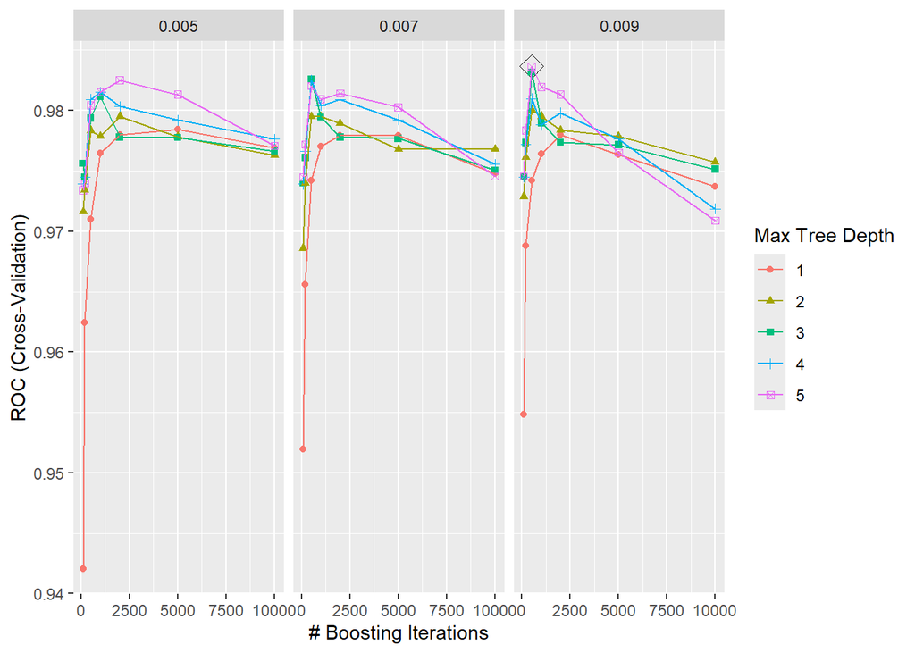

```r
ctrl <- trainControl(method = "cv", classProbs = TRUE, summaryFunction = twoClassSummary)

# Boosting
gbmA.grid <- expand.grid(n.trees = c(100,200,500,1000,2000,5000,10000),
            interaction.depth = 1:5,
            shrinkage = c(0.005,0.007,0.009),
            n.minobsinnode = c(10))

set.seed(2)
boost.fit <- train(mpg_cat ~ .,
                   training_data,
                   tuneGrid = gbmA.grid,
                   trControl = ctrl,
                   method = "gbm",
                   distribution = "adaboost",
                   metric = "ROC",
                   verbose = FALSE)

ggplot(boost.fit, highlight = TRUE)
```

```r
# Training Error Rate
pred.gbm.train <- predict(boost.fit, newdata = training_data)
train.error.gbm <- mean(pred.gbm.train != training_data$mpg_cat)

# Test Error Rate
pred.gbm.test <- predict(boost.fit, newdata = testing_data)
test.error.gbm <- mean(pred.gbm.test != testing_data$mpg_cat)

# Results
cat("Boosting Training Error:", train.error.gbm, "\n")
```

```
## Boosting Training Error: 0.02583026
```

```r
cat("Boosting Test Error:", test.error.gbm, "\n")
```

```
## Boosting Test Error: 0.05982906
```

```r
# Overall test error Comparison
cat("SVC Test Error:", round(test_err_lin, 4), "\n")
```

```
## SVC Test Error: 0.0855
```

```r
cat("SVM Test Error:", round(test_err_rad, 4), "\n")
```

```
## SVM Test Error: 0.0684
```

```r
cat("Boosting Test Error:", round(test.error.gbm, 4), "\n")
```

```
## Boosting Test Error: 0.0598
```

The Boosting model achieved the lowest test error rate (0.0598), likely because the algorithm could iteratively correct misclassifications that the SVM models could not. While the Radial SVM (0.0684) performed better than the Linear SVC (0.0855), Boosting provided the most robust predictive performance for the data.

### 2-a. Hierarchical Clutering

```r
# Hierarchical Clustering with Complete Linkage
states_data <- USArrests
hc_complete <- hclust(dist(states_data), method = "complete")

clusters <- cutree(hc_complete, k = 3)

sort(clusters)
```

```
##        Alabama         Alaska        Arizona     California       Delaware
##              1              1              1              1              1
##        Florida       Illinois      Louisiana       Maryland       Michigan
##              1              1              1              1              1
##    Mississippi         Nevada     New Mexico       New York North Carolina
##              1              1              1              1              1
## South Carolina       Arkansas       Colorado        Georgia  Massachusetts
##              1              2              2              2              2
##       Missouri     New Jersey       Oklahoma         Oregon   Rhode Island
##              2              2              2              2              2
##      Tennessee          Texas       Virginia     Washington        Wyoming
##              2              2              2              2              2
##    Connecticut         Hawaii          Idaho        Indiana           Iowa
##              3              3              3              3              3
##         Kansas       Kentucky          Maine      Minnesota        Montana
##              3              3              3              3              3
##       Nebraska  New Hampshire   North Dakota           Ohio   Pennsylvania
##              3              3              3              3              3
##   South Dakota           Utah        Vermont  West Virginia      Wisconsin
##              3              3              3              3              3
```

```r
table(clusters)
```

```
## clusters
##  1  2  3
## 16 14 20
```

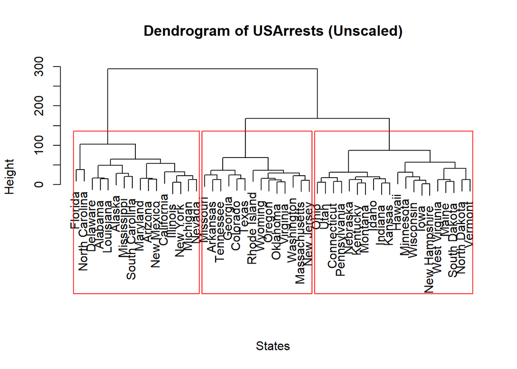

```r
# dendrogram
plot(hc_complete, main = "Dendrogram of USArrests (Unscaled)", xlab = "States", sub = "")

rect.hclust(hc_complete, k = 3, border = "red")
```

This dendrogram visuzalizes the states that make up each cluster. 16 states were in cluster 1, 14 in cluster 2 and 20 in cluster 3.

Cluster 1: Alabama, Alaska, Arizona, California, Delaware, Florida, Illinois, Louisiana, Maryland, Michigan, Mississippi, Nevada, New Mexico, New York, North Carolina, South Carolina.

Cluster 2: Arkansas, Colorado, Georgia, Massachusetts, Missouri, New Jersey, Oklahoma, Oregon, Rhode Island, Tennessee, Texas, Virginia, Washington, Wyoming.

Cluster 3: Connecticut, Hawaii, Idaho, Indiana, Iowa, Kansas, Kentucky, Maine, Minnesota, Montana, Nebraska, New Hampshire, North Dakota, Ohio, Pennsylvania, South Dakota, Utah, Vermont, West Virginia, Wisconsin.

### 2-b. Scaling

```r
# Scaling (standard deviation = 1)
states_scaled <- scale(USArrests)

# Hierarchical clustering with complete linkage and Euclidean distance
hc_scaled <- hclust(dist(states_scaled), method = "complete")

clusters_scaled <- cutree(hc_scaled, k = 3)

table(clusters_scaled)
```

```
## clusters_scaled
##  1  2  3
##  8 11 31
```

```r
# Comparing
table(Unscaled = clusters, Scaled = clusters_scaled)
```

```
##         Scaled
## Unscaled  1  2  3
##        1  6  9  1
##        2  2  2 10
##        3  0  0 20
```

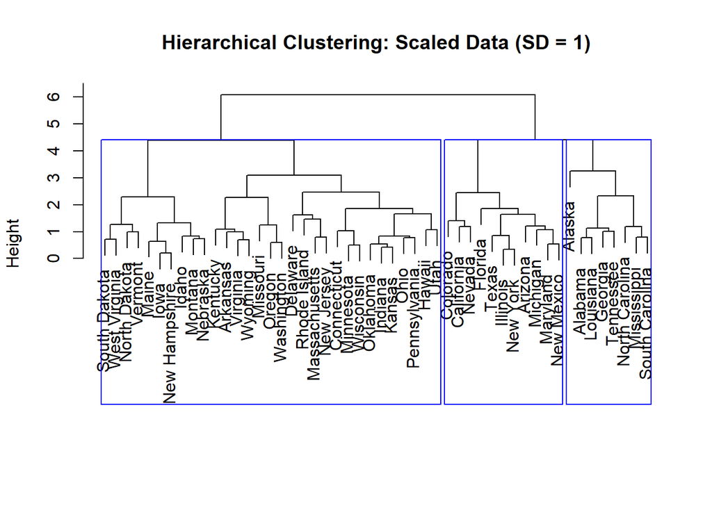

```r
# Scaled data dendrogram
plot(hc_scaled, main = "Hierarchical Clustering: Scaled Data (SD = 1)", xlab = "", sub = "")
rect.hclust(hc_scaled, k = 3, border = "blue")
```

Scaling the variables significantly changed the clustering results. The table shows that only 6 of the original 16 states in the unscaled clusters remained with 9 moving to cluster 2 and 1 moving to cluster 3. Out of the original 14 in the unscaled cluster 2, 2 were shifted to cluster 1 and 10 were shifted to cluster 3. The original states in cluster 3 all remained but 11 more moved into this cluster after scaling, indicating that it was the most stable of the three unscaled clusters. The scaled data yielded 8 states in cluster 1, 11 states in cluster 2 and 31 states in cluster 3. The dendrogram visualizes the scaled data clusters to highlight the differences.

In my opinion, the data should absolutely be scaled prior to inter-observation computation of dissimilarities because otherwise the variables on a small scale like murder (~10^1 scale) get largely ignored by the model as the variables on a larger scale like assault (~10^2 scale) over power the results. Scaling the data puts the clustering on an even field.